# Examining the Decline of Save Percentage in the NHL

Quinn Robnett and Luke Welsh

2023-07-27

## Introduction

Goaltending in the NHL is of vital importance. A goalie’s job is simple: stop the other team from scoring. Good (and timely) goaltending can be the difference between a mediocre team and a team that goes on a deep run in the playoffs. Many of the best “underdog” or “cinderella” playoff runs can be attributed to a goaltender getting hot. For example, just this year, the 8-seed Florida Panthers made a run to the Stanley Cup Final on the back of Sergei Bobrovsky, who put up remarkable numbers in the playoffs.

Individual goaltending is hard, if not impossible, to predict on a year-to-year basis. The “best” goalies seem to change each year (a total of 12 different goalies have been Vezina trophy finalists over the past five seasons, with only two appearing more than once). It isn’t uncommon for a goalie to follow up a spectacular year with an unremarkable one, or vice versa. Take Jakob Markstrom, for example, who in 2021-22 was a finalist for the Vezina trophy with a .922 save percentage (SV%) and a 2.22 goals against average (GAA). The following season, he posted an .892 SV% and a 2.92 GAA. Individual goaltending may be hard to predict, but one might expect league averages to be similar on a year-to-year basis. However, over the last handful of seasons, a striking anomaly has made itself present.

#### Save Percentage by Year

##### Plot

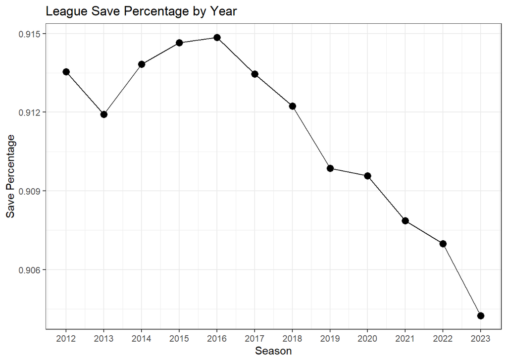

##### Table

| Season | SV | SOG | G | SV% |
| --- | --- | --- | --- | --- |
| 2012 | 66638 | 72945 | 6307 | 0.9135 |
| 2013 | 38143 | 41827 | 3684 | 0.9119 |
| 2014 | 67333 | 73682 | 6349 | 0.9138 |
| 2015 | 67050 | 73307 | 6257 | 0.9146 |
| 2016 | 66587 | 72784 | 6197 | 0.9149 |
| 2017 | 67638 | 74046 | 6408 | 0.9135 |
| 2018 | 73774 | 80872 | 7098 | 0.9122 |
| 2019 | 72371 | 79540 | 7169 | 0.9099 |
| 2020 | 61522 | 67638 | 6116 | 0.9096 |
| 2021 | 46995 | 51764 | 4769 | 0.9079 |
| 2022 | 74837 | 82511 | 7674 | 0.9070 |
| 2023 | 73728 | 81535 | 7807 | 0.9042 |

## Data Summary

We used two data sets for our analysis. The first was pulled from Hockey Reference and includes yearly goalie stats for every goalie that has appeared in an NHL game from 2011-12 to 2022-23. Important variables in this data set include season, games played (GP), games started (GS), goals against (GA), shots against (SA), saves (SV), and save percentage (SV%).

##### Snippet of Hockey Reference Goalie Data

| Player | Age | Team | Season | GP | GS | W | L | OT | GA | SA | SV | SV% | GAA |
| --- | --- | --- | --- | --- | --- | --- | --- | --- | --- | --- | --- | --- | --- |
| Connor Hellebuyck | 29 | WPG | 2023 | 64 | 64 | 37 | 25 | 2 | 157 | 1964 | 1807 | 0.920 | 2.49 |
| Juuse Saros | 27 | NSH | 2023 | 64 | 63 | 33 | 23 | 7 | 171 | 2099 | 1928 | 0.919 | 2.69 |
| Alexandar Georgiev | 26 | COL | 2023 | 62 | 62 | 40 | 16 | 6 | 156 | 1904 | 1748 | 0.918 | 2.53 |
| Jake Oettinger | 24 | DAL | 2023 | 62 | 61 | 37 | 11 | 11 | 144 | 1776 | 1632 | 0.919 | 2.37 |
| Ilya Sorokin | 27 | NYI | 2023 | 62 | 60 | 31 | 22 | 7 | 140 | 1838 | 1698 | 0.924 | 2.34 |
| Jordan Binnington | 29 | STL | 2023 | 61 | 60 | 27 | 27 | 6 | 194 | 1826 | 1632 | 0.894 | 3.31 |

Our second data set is event-level play-by-play data courtesy of the hockeyR package (https://github.com/danmorse314/hockeyR) created by Dan Morse. The package scrapes and cleans play-by-play data from the NHL website. We used it to scrape data from the 2011-12 to 2022-23 season, and the resulting data set had over 4 million rows of event data. Important variables in this data set include game ID, event type, x and y coordinates of each event, strength code, shot distance, and shot angle (the full data set consists of over 100 attributes).

#### Snippet of hockeyR Play by Play Data

| event_type | event_team | event_team_type | period | period_time | game_seconds_remaining | shot_distance | shot_angle | x_fixed | y_fixed |
| --- | --- | --- | --- | --- | --- | --- | --- | --- | --- |
| GAME_SCHEDULED | NA | NA | 1 | 00:00 | 3600 | NA | NA | NA | NA |
| FACEOFF | Boston Bruins | home | 1 | 00:00 | 3600 | NA | NA | 0 | 0 |
| GIVEAWAY | Philadelphia Flyers | away | 1 | 00:14 | 3586 | NA | NA | -13 | 1 |
| SHOT | Boston Bruins | home | 1 | 00:47 | 3553 | 58.7 | 13.8 | 32 | -14 |
| MISSED_SHOT | Boston Bruins | home | 1 | 01:01 | 3539 | 37.1 | 3.1 | 52 | -2 |
| HIT | Philadelphia Flyers | away | 1 | 01:12 | 3528 | NA | NA | 10 | -36 |

*Note*: Any time a season is referenced, it refers to the year the season **concluded** (for example, the 2011-12 season will appear as ‘2012’)

## Exploratory Data Analysis

There are many potential explanations for the drastic decline in save percentage. The simplest hypothesis is that goalies have gotten worse. While this could be the case, our inclination is to believe that something else could be going on. So going forward, we will operate under the assumption that the relative skill of goaltenders has not changed.

#### Hypothesis #1: Worse Goalies are Playing More

Our first idea at what could be explaining the decline is simple: worse goalies are playing more. Each team has two goalies on the roster. Typically, one goalie will be the designated “starter” and get the majority of starts, while the “backup” will play a handful of games to help the starter get some rest. In some cases, a team will run a “tandem” where both their goalies are of a similar level and get a similar amount of starts, although this is much less common. Simply put, it’s a possibility that teams are giving their starters more rest, which could lead to save percentage dropping on average.

#### Percentage of Games Started by a Starter

##### Plot

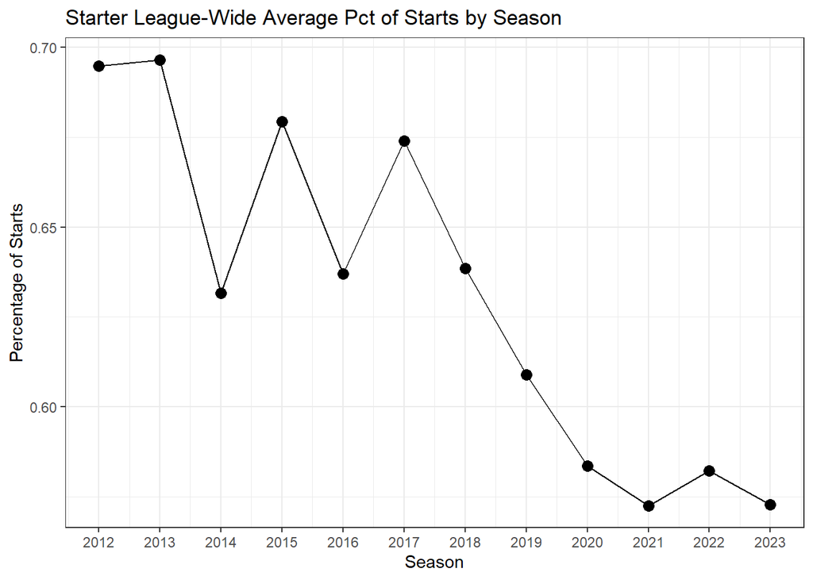

##### Table

[output not shown]

*Note*: You’ll notice that in the 2020 season, the number of games played in the season was approximately 70.58. This is due to the season being cut short for the COVID-19 pandemic, leaving teams with a differing number of games played.

We observe that this is indeed the case. In the figure above, a starter was considered to be the goalie who played in the most games for a team over the course of a season. In general, the percentage of games a starter plays in has declined in a similar manner to save percentage. While this may be a contributing factor to the overall decline in save percentage, the figure below shows that there is something else going on.

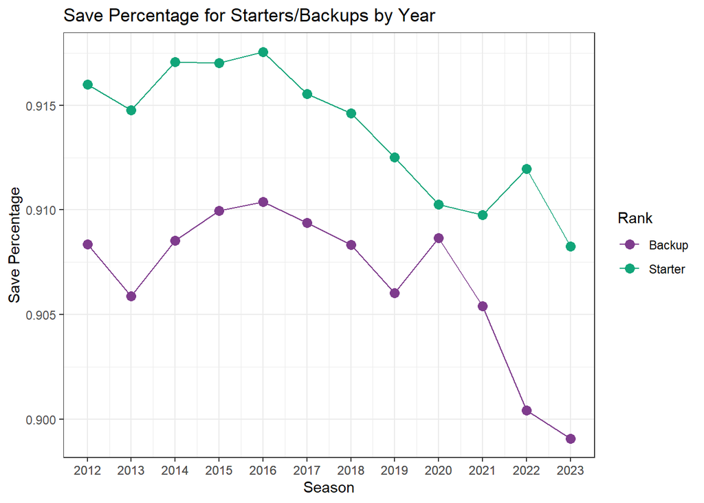

Unsurprisingly, it is clear that starters’ save percentages are better than the backups’ (any non-starter). But, even so, for both backups and starters, a decline in save percentage is still present. Even if we narrow it down to the top 15 starters by year based on save percentage, we still observe a decline:

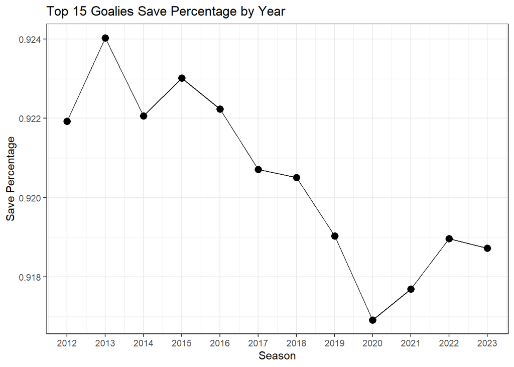

#### Hypothesis 2: Increase in Power Plays

A power play consists of one team having more players on the ice than the other team due to penalties. Is it possible that an increase in power plays is contributing to a decline in save percentage? As seen in the figures below, the answer is a resounding no. In fact, power play opportunities have also been trending down, until a recent spike in 2023. Power play shots per game hit a low in 2019 before bouncing back and has been rising since, despite the decline in power play opportunities.

#### Power Plays by Year

##### Opportunities

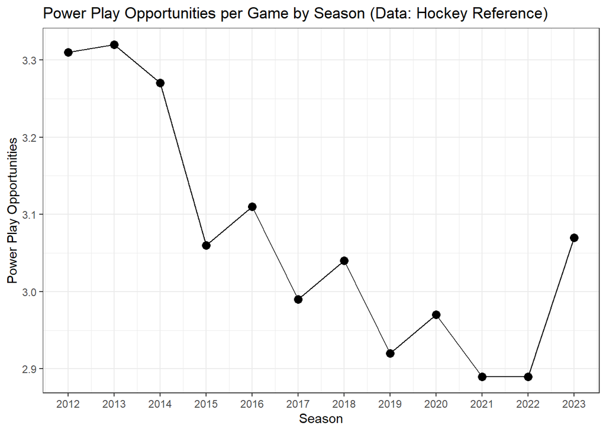

##### Shots

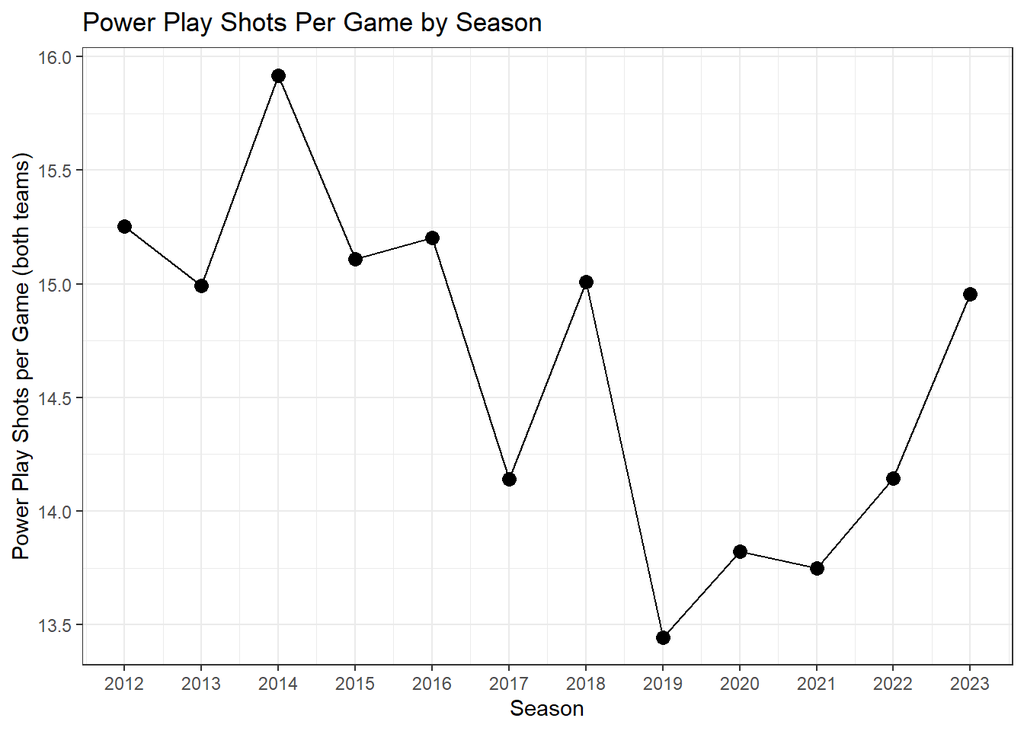

We also observe a decline in save percentage for both even strength and power play situations. Interestingly, the decline in save percentage for even strength seems to start much later than that of power plays. Power play save percentage seems to start declining after 2014, whereas save percentage for even strength remains mostly constant through 2017 before taking a drop.

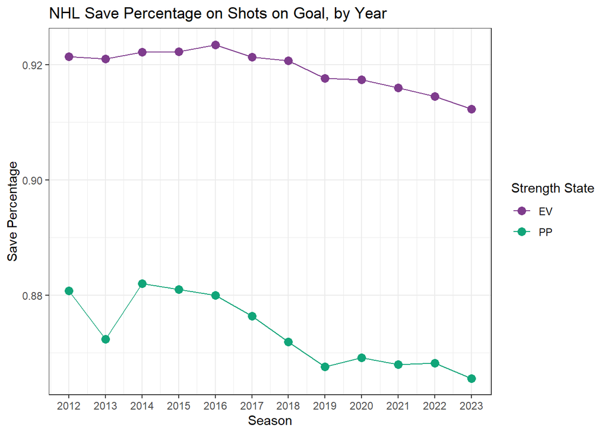

#### Hypothesis 3: Shooters are Becoming More Effective

Up to this point, we have ignored a key aspect of scoring goals: the shooter. After all, shooting percentage (goals/shots on goal) and save percentage will always add up to 1. If goalies aren’t getting worse, it’s logical to think the decline in save percentage has more to do with shooters becoming more effective.

Not only do we want to know if this is the case, but we want to understand how shooters have gotten better. To accomplish this, we turned to building an expected goals model. An expected goals (xG) model is a prediction model that calculates the likelihood of a shot being a goal given shots with similar characteristics in the past. Often times, these predictive models are trained on many seasons of data. However, our aim was to build an xG model on each season of data to analyze the coefficients for certain shot attributes. This is so we can observe whether the way players are scoring goals has fundamentally changed over time.

## Methods

#### Data Transformation

To get the play-by-play data ready to build the model, we first filtered out any shootout and penalty shot events and filtered by Fenwick events (shots, missed shots, goals). We then created the following variables (with help from code given by the hockeyR package):

- Rush - TRUE when preceded by a neutral/defensive zone event four or less seconds prior
- Rebound - TRUE when preceded by a Fenwick event two or less seconds prior
- Angle Change - Difference in angle from previous shot for shots classified as rebounds
- Cross Ice - TRUE when preceded by an offensive zone event on the opposite side of the ice two or less second prior
- Forecheck - TRUE when preceded by a takeaway/giveaway in the offensive zone two or less seconds prior

We believe that these are important factors to consider as to how goals are scored. We understand that creating these variables has limitations. Not every shot will be perfectly classified using this method, but we believe it will be sufficient to show any patterns in goal scoring.

#### Model Building

Once the data were cleaned and transformed, we built logistic models for even strength xG and power play xG separately. We decided to withhold building a shorthanded model given the infrequency and inherent oddness of shorthanded shot attempts. These are the explanatory variables we used in each model:

- Shot Distance
- Shot Angle
- Rush Event (Boolean)
- Rebound Event (Boolean)
- Rebound Event X Angle Change (Interaction Term)
- Cross Ice Event (Boolean)
- Forecheck - Even strength only (Boolean)

We did not use the forechecking variable for the power play model, because only a small percentage of Fenwick events on the power play were classified as forechecking. This makes intuitive sense as teams generally try for controlled zone entries on the power play as opposed to a “dump and chase”.

After building the framework for the models, we trained a model for every individual season of data going back to the 2011-12 season.

## Results

#### Shot Distance

##### Coefficients

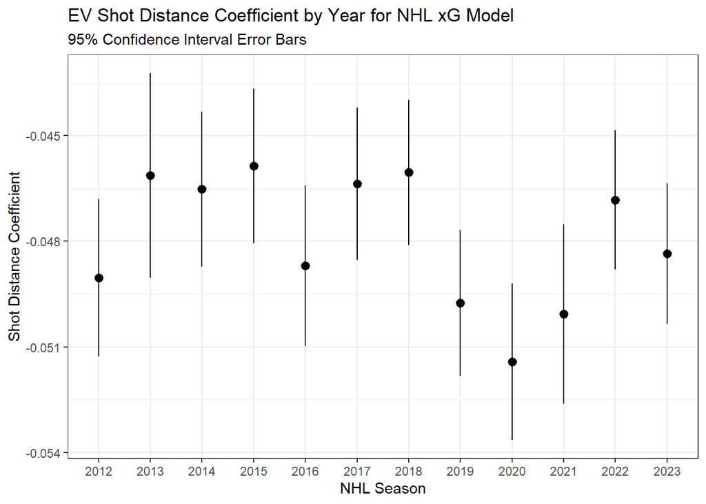

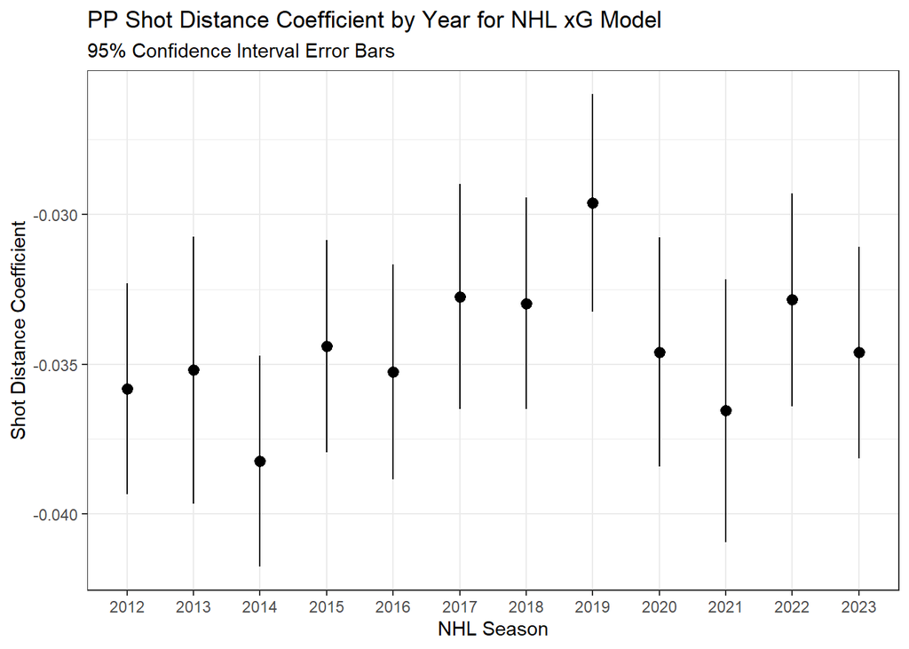

##### Frequency

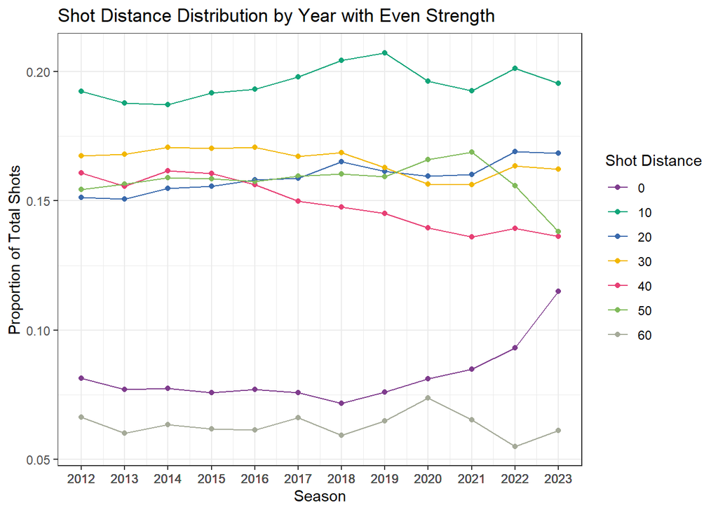

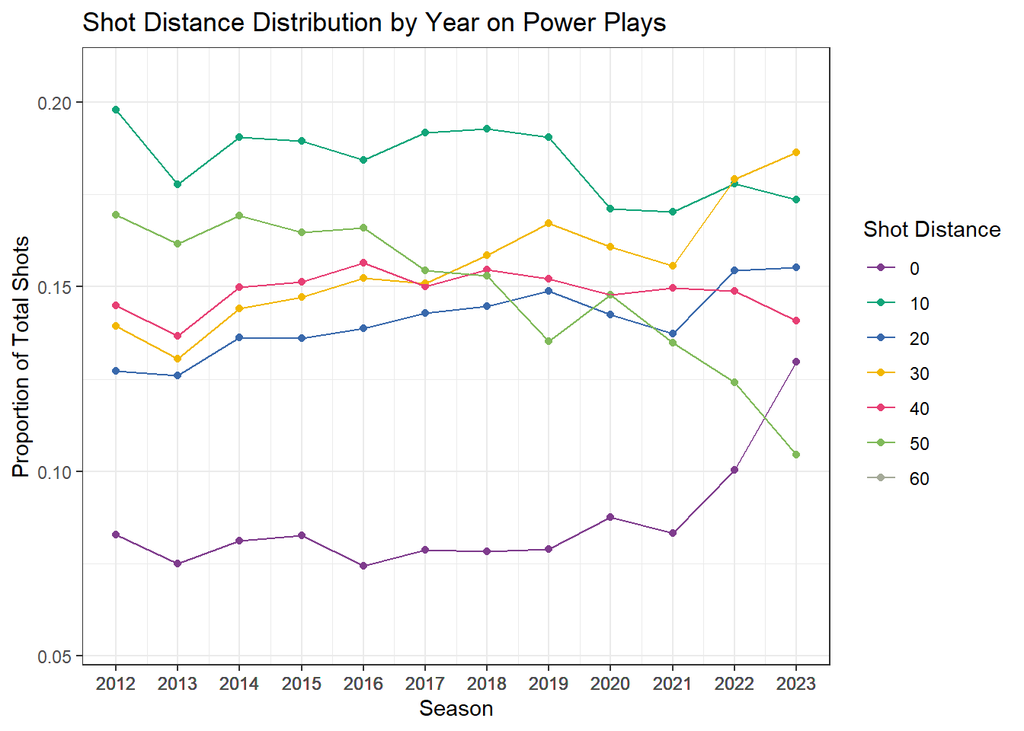

##### Save Percentage

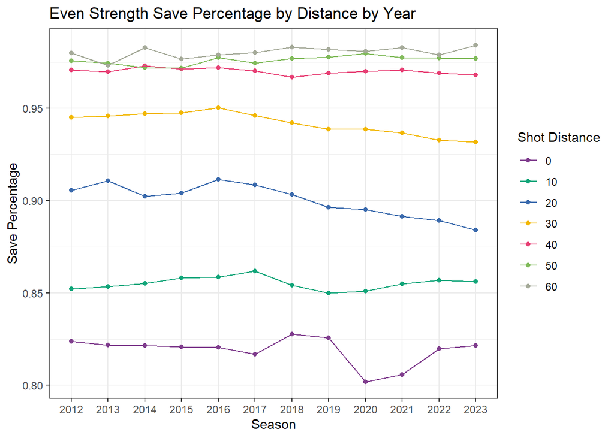

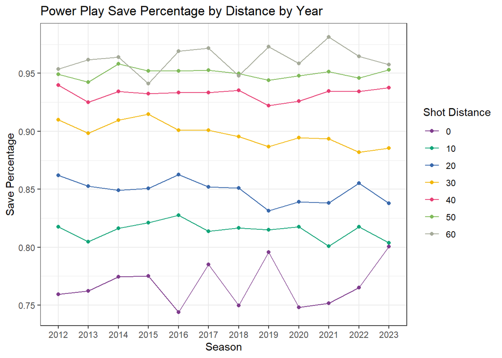

Interestingly, the data show a significant spike in the percentage of Fenwick events in the 0-10 foot range over the past few seasons for both even strength and power play. On the power play, there appears to be a steady increase in 20-30 and 30-40 ft shots.

Even more interesting is the save percentage on shots from certain ranges. For most bins of distances on both even strength and power play, save percentage has stayed relatively consistent. However, we see the decline in the 20-30 and 30-40 ft range for both strengths, and in the 10-20 ft range for power play. This effect is even more apparent when expanding the bin range to 20:

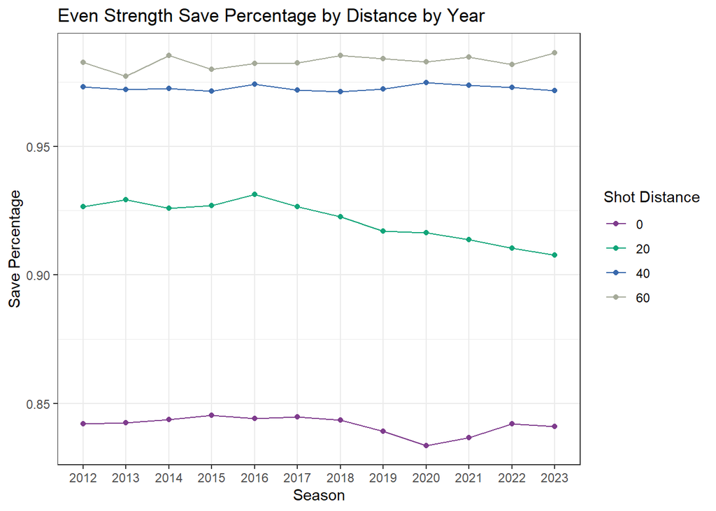

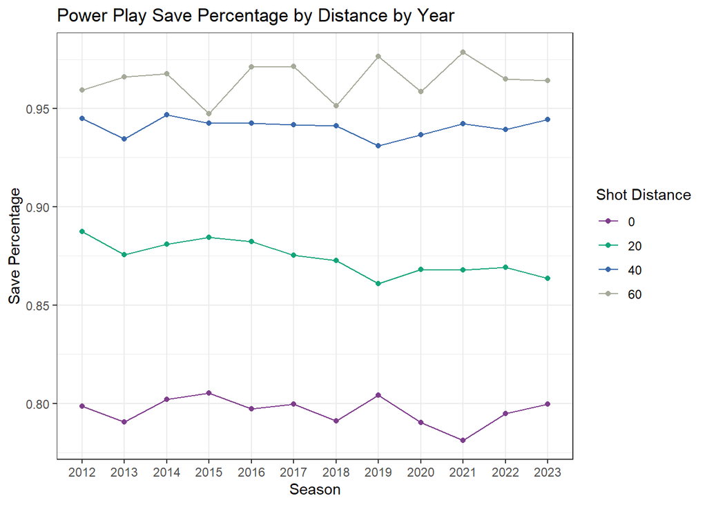

Over time, goalies have been saving fewer shots from 20-40 feet. It is unlikely the play of goalies has declined just for shots of this distance. More likely is that shooters have gotten better at shooting these shots and they are taking more of them, as can be seen on power plays.

#### Shot Angle

##### Coefficients

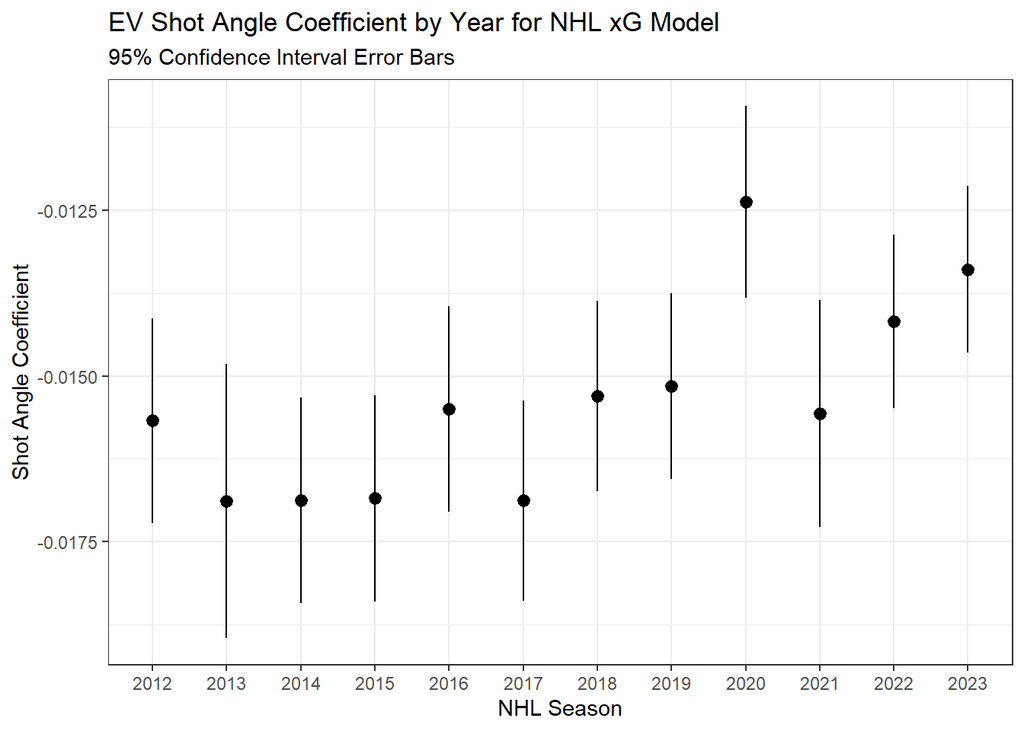

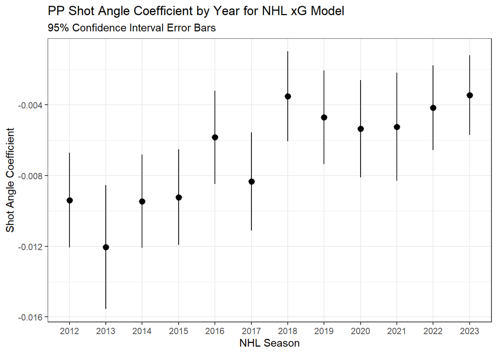

##### Frequency

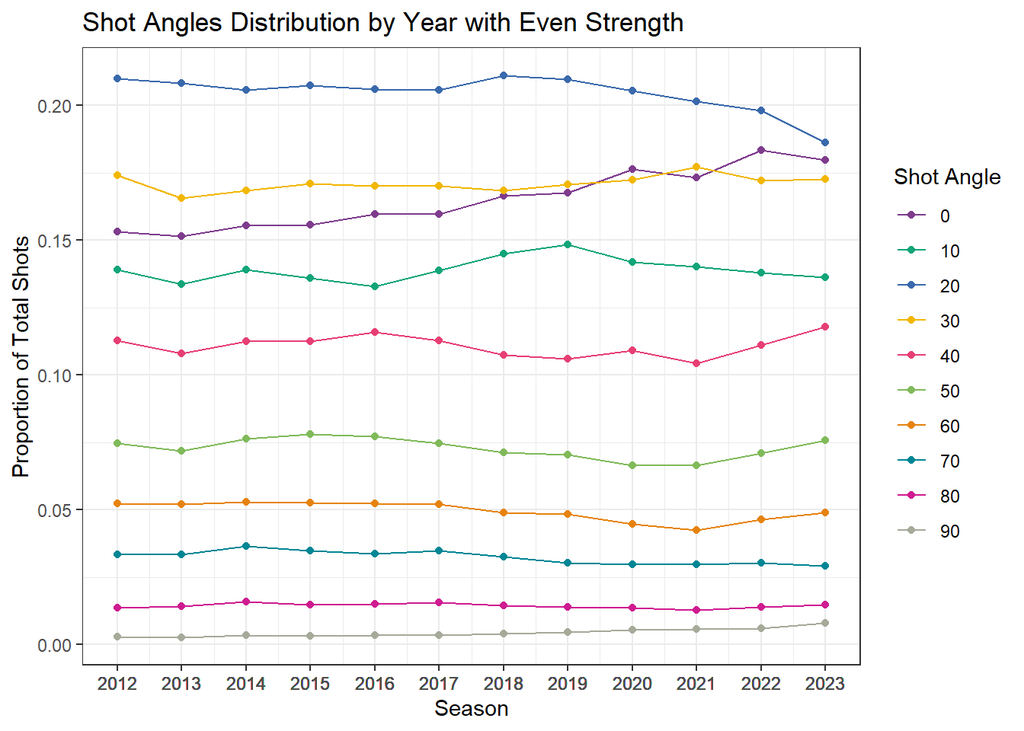

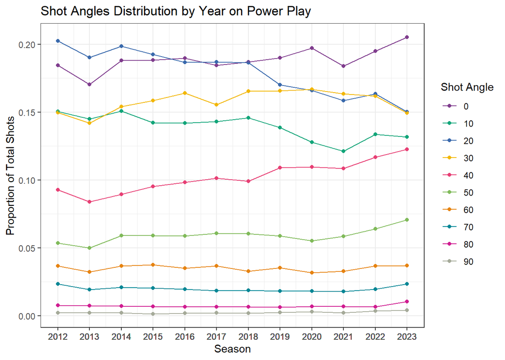

##### Save Percentage

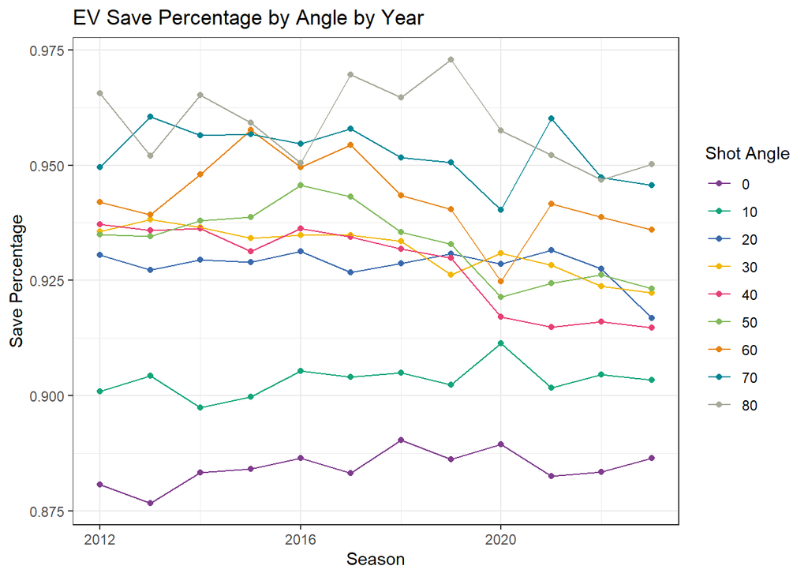

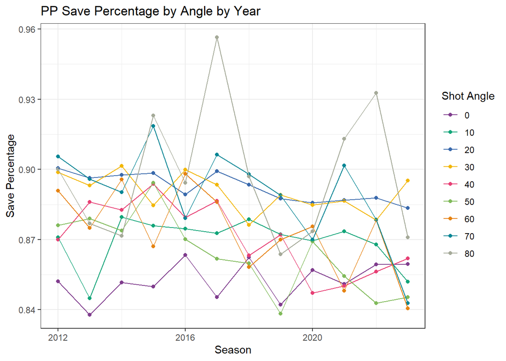

Similar to the distance coefficients, the shot angle coefficients for both even strength and power play are negative across all seasons. Shot angle is measured in degrees from the middle of the ice (a shot with angle 0 is directly in front of the goalie; a shot with angle 90 is from the goal line). Therefore, it is no surprise that as shot angle increases, the log odds of scoring decreases. What’s interesting is the general upward trends (closer to 0) in the coefficients in both strength states. In general, this means increasing shot angle is more likely to be a goal than it once was. Once again, this could mean that shooters have improved at scoring from tougher angles. We see that even strength save percentage has declined for most angles above 20 degrees, and power play save percentage seems to be quite random.

#### Rebound Events

##### Coefficients

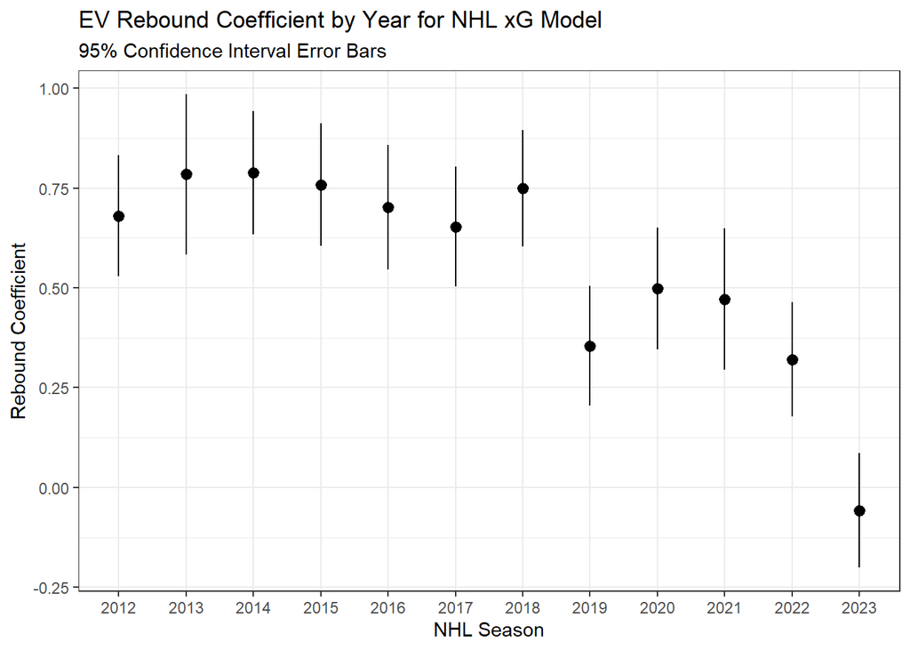

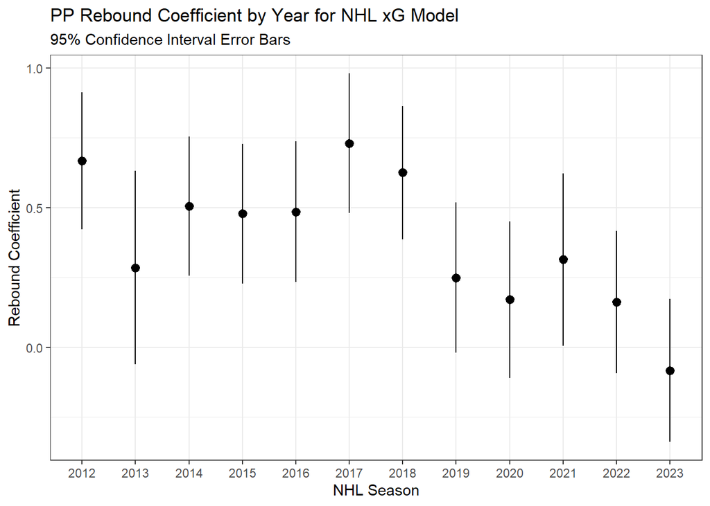

##### Frequency

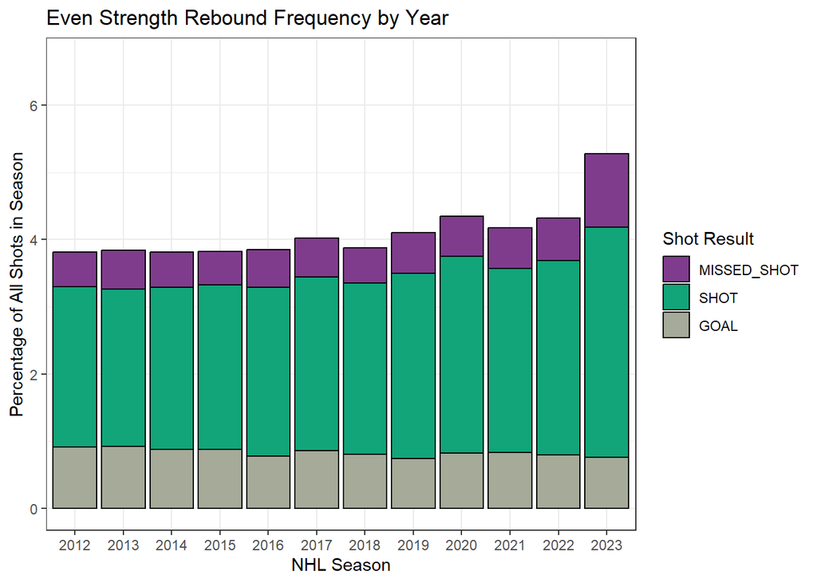

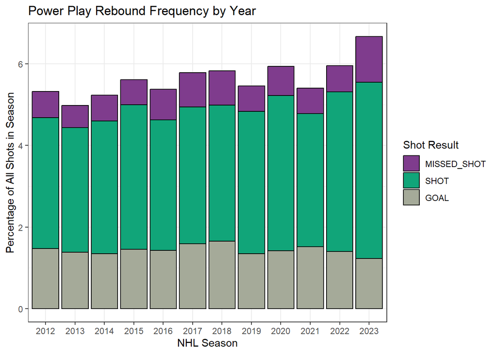

##### Save Percentage

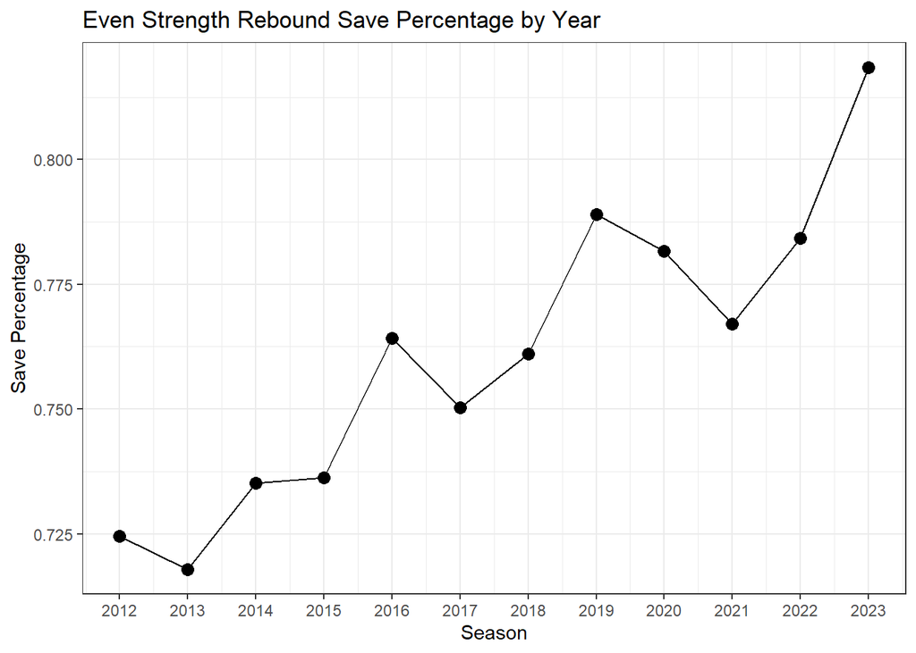

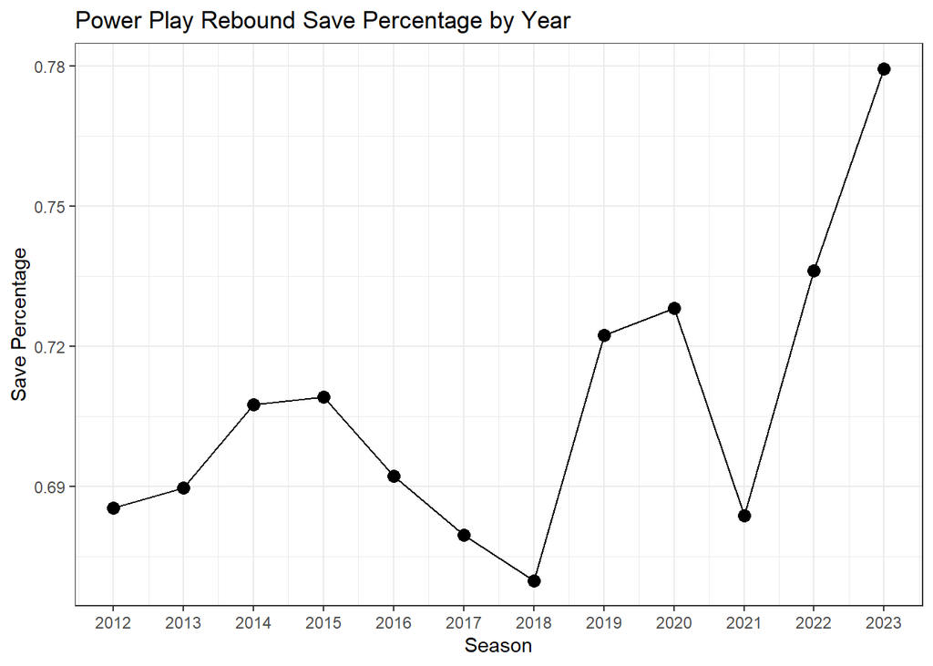

#### Rush Events

##### Coefficients

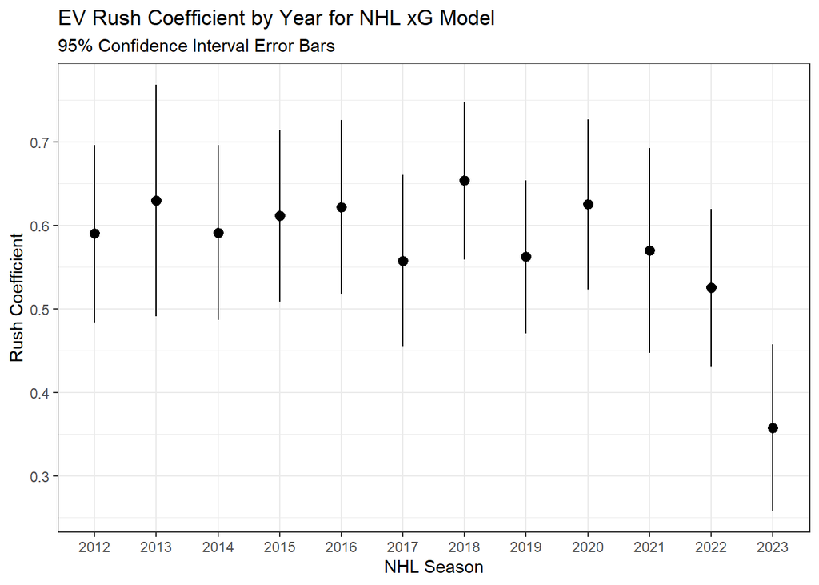

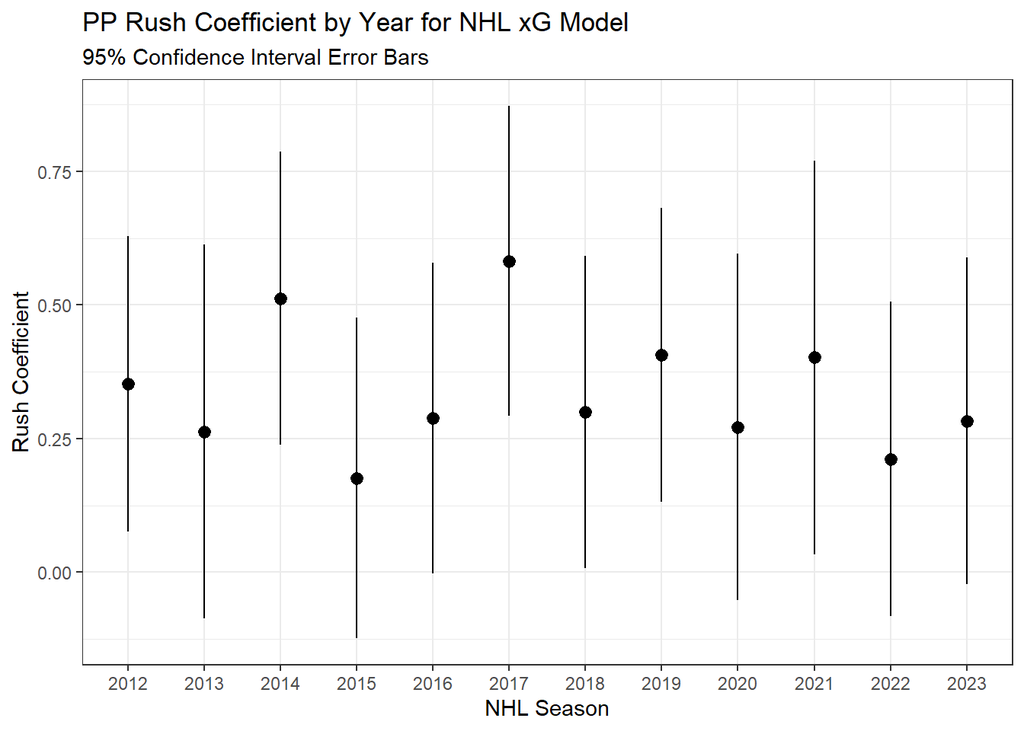

##### Frequency

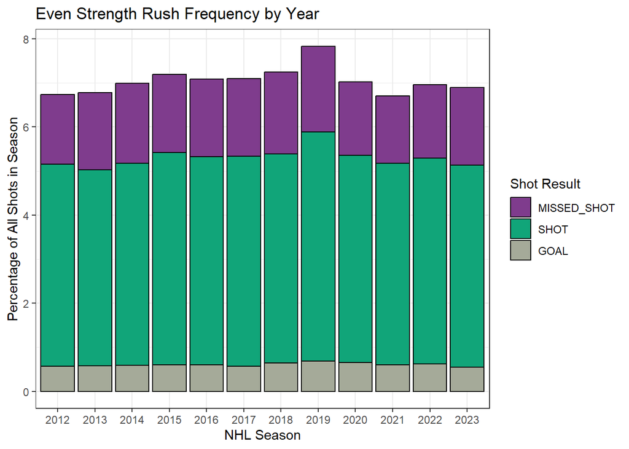

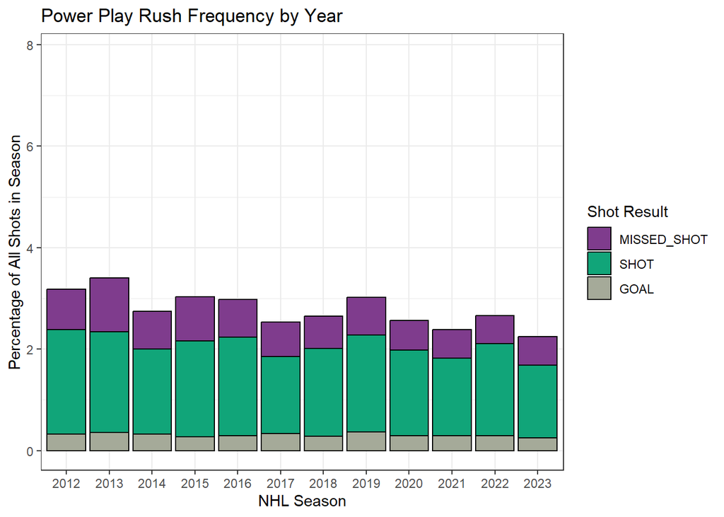